# Análisis exploratrio de las barreras burocráticas en el Perú

De acuerdo con la CEB-Indecopi

Abner Francisco Casallo Trauco

2020-08-09

# Antes de empresar veamos la fuente…

# Indecopi

El Instituto Nacional de Defensa de la Competencia y de la Protección de la Propiedad Intelectual, es un organismo público autónomo especializado del Estado Peruano, adscrito a la Presidencia del Consejo de Ministros, con personería jurídica de derecho público.

[figure not shown]

# ANÁLISIS DEL TRATAMIENTO DE LAS BARRERRAS BUROCRÁTICAS POR LA CEB

### Consideraciones preliminares

En este apartado analizaremos diversos aspectos en el tratamiento de las barreras burocráticas por parte de la CEB . Se abordarán aspectos como *cuál es el tipo de entidad que emite más barreras*, *¿hay reversión de las barreras?*, entre otros aspectos.

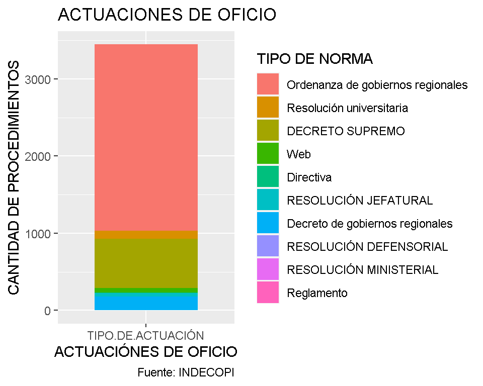

FUENTES DE LAS BARRERAS DISCUTIDAS DE OFICIO

### ¿QUÉ ENTIDAD EMITE MÁS BARRERAS Y LAS REVIERTE?

Una pregunta preliminar que surge es ¿qué entidad está dificultando más la actividad económica? En el gráfico“Barreras por entidad y análisis de reversión” uno puedo observar la respuesta a ello. La respuesta para ambascuestiones es la de los gobiernos regionales. De hecho, el resultado no genera ninguna sorpresa. De acuerdo con las investigaciones sobre la materia, la demora en la tramitación así como la excesiva regulación están dentro de los principales obstáculos para el desarrollo de negocios en el Perú, lo cual a su vez se vincula con escenarios de corrupción (DALY, Jorge y NAVAS, Óscar: 2015).

Asimismo, de acuerdo con el ranking de barreras burocráticas eliminadas voluntariamente en el 2019, las 27 primeras son Municipalidades. La conclusión que podemos obtener de todo esto es que las reformas destinadas a reducir los obstáculos al desarrollo empresarial deben estar cocentradas en buena parte a nivel municipal/regional.

[figure not shown]

### ¿QUÉ TIPO DE BARRERA NOS DEBERÍA PREOCUPAR MÁS?

Una vez que hemos observado que los gobiernos regionales son los principales productores de barreras, la pregunta siguiente es ¿qué tipo de barrera es la que uno encuentra más en la práctica? Este asunto es importante, pues en la práctica las barreras tienen disntintas formas de materializarse. Como se observa en el gráfico, las ordenanzas de los gobiernos regionales son las principales barreras a considerar.

[figure not shown]